# Risk Factor Analysis

## Outcome Variable

**Outcome Variable:** wasted

## Predictor Variables

**Intervention Variable:** rain_quartile

**Adjustment Set:**

unadjusted

## Stratifying Variables

The analysis was stratified on these variable(s):

- studyid
- country
- agecat

## Data Summary

| studyid | country | agecat | rain_quartile | wasted | n_cell | n |
| --- | --- | --- | --- | --- | --- | --- |
| CMC-V-BCS-2002 | India | Birth | 1 | 0 | 14 | 86 |
| CMC-V-BCS-2002 | India | Birth | 1 | 1 | 3 | 86 |
| CMC-V-BCS-2002 | India | Birth | 2 | 0 | 17 | 86 |
| CMC-V-BCS-2002 | India | Birth | 2 | 1 | 5 | 86 |
| CMC-V-BCS-2002 | India | Birth | 3 | 0 | 27 | 86 |
| CMC-V-BCS-2002 | India | Birth | 3 | 1 | 1 | 86 |
| CMC-V-BCS-2002 | India | Birth | 4 | 0 | 17 | 86 |
| CMC-V-BCS-2002 | India | Birth | 4 | 1 | 2 | 86 |
| CMC-V-BCS-2002 | India | 6 months | 1 | 0 | 95 | 368 |
| CMC-V-BCS-2002 | India | 6 months | 1 | 1 | 7 | 368 |
| CMC-V-BCS-2002 | India | 6 months | 2 | 0 | 101 | 368 |
| CMC-V-BCS-2002 | India | 6 months | 2 | 1 | 8 | 368 |
| CMC-V-BCS-2002 | India | 6 months | 3 | 0 | 78 | 368 |
| CMC-V-BCS-2002 | India | 6 months | 3 | 1 | 19 | 368 |
| CMC-V-BCS-2002 | India | 6 months | 4 | 0 | 48 | 368 |
| CMC-V-BCS-2002 | India | 6 months | 4 | 1 | 12 | 368 |
| CMC-V-BCS-2002 | India | 24 months | 1 | 0 | 98 | 372 |
| CMC-V-BCS-2002 | India | 24 months | 1 | 1 | 3 | 372 |
| CMC-V-BCS-2002 | India | 24 months | 2 | 0 | 92 | 372 |
| CMC-V-BCS-2002 | India | 24 months | 2 | 1 | 7 | 372 |
| CMC-V-BCS-2002 | India | 24 months | 3 | 0 | 109 | 372 |
| CMC-V-BCS-2002 | India | 24 months | 3 | 1 | 8 | 372 |
| CMC-V-BCS-2002 | India | 24 months | 4 | 0 | 50 | 372 |
| CMC-V-BCS-2002 | India | 24 months | 4 | 1 | 5 | 372 |
| CMIN | Bangladesh | Birth | 1 | 0 | 4 | 19 |
| CMIN | Bangladesh | Birth | 1 | 1 | 0 | 19 |
| CMIN | Bangladesh | Birth | 2 | 0 | 4 | 19 |
| CMIN | Bangladesh | Birth | 2 | 1 | 1 | 19 |
| CMIN | Bangladesh | Birth | 3 | 0 | 3 | 19 |
| CMIN | Bangladesh | Birth | 3 | 1 | 2 | 19 |

[output cut: 506 more lines]

The following strata were considered:

- studyid: CMC-V-BCS-2002, country: India, agecat: 24 months
- studyid: CMC-V-BCS-2002, country: India, agecat: 6 months
- studyid: CMC-V-BCS-2002, country: India, agecat: Birth
- studyid: CMIN, country: Bangladesh, agecat: 24 months
- studyid: CMIN, country: Bangladesh, agecat: 6 months
- studyid: CMIN, country: Bangladesh, agecat: Birth
- studyid: CONTENT, country: Peru, agecat: 24 months
- studyid: CONTENT, country: Peru, agecat: 6 months
- studyid: CONTENT, country: Peru, agecat: Birth
- studyid: EE, country: Pakistan, agecat: 24 months
- studyid: EE, country: Pakistan, agecat: 6 months
- studyid: EE, country: Pakistan, agecat: Birth
- studyid: GMS-Nepal, country: Nepal, agecat: 24 months
- studyid: GMS-Nepal, country: Nepal, agecat: 6 months
- studyid: GMS-Nepal, country: Nepal, agecat: Birth
- studyid: Guatemala BSC, country: Guatemala, agecat: 6 months
- studyid: IRC, country: India, agecat: 24 months
- studyid: IRC, country: India, agecat: 6 months
- studyid: IRC, country: India, agecat: Birth
- studyid: JiVitA-3, country: Bangladesh, agecat: 24 months
- studyid: JiVitA-3, country: Bangladesh, agecat: 6 months
- studyid: JiVitA-3, country: Bangladesh, agecat: Birth
- studyid: JiVitA-4, country: Bangladesh, agecat: 24 months
- studyid: JiVitA-4, country: Bangladesh, agecat: 6 months
- studyid: JiVitA-4, country: Bangladesh, agecat: Birth
- studyid: Keneba, country: Gambia, agecat: 24 months
- studyid: Keneba, country: Gambia, agecat: 6 months
- studyid: Keneba, country: Gambia, agecat: Birth
- studyid: LCNI-5, country: Malawi, agecat: 24 months
- studyid: LCNI-5, country: Malawi, agecat: 6 months
- studyid: MAL-ED, country: Bangladesh, agecat: 24 months
- studyid: MAL-ED, country: Bangladesh, agecat: 6 months
- studyid: MAL-ED, country: Bangladesh, agecat: Birth
- studyid: MAL-ED, country: Brazil, agecat: 24 months
- studyid: MAL-ED, country: Brazil, agecat: 6 months
- studyid: MAL-ED, country: Brazil, agecat: Birth
- studyid: MAL-ED, country: India, agecat: 24 months
- studyid: MAL-ED, country: India, agecat: 6 months
- studyid: MAL-ED, country: India, agecat: Birth
- studyid: MAL-ED, country: Nepal, agecat: 24 months
- studyid: MAL-ED, country: Nepal, agecat: 6 months
- studyid: MAL-ED, country: Nepal, agecat: Birth
- studyid: MAL-ED, country: Peru, agecat: 24 months
- studyid: MAL-ED, country: Peru, agecat: 6 months
- studyid: MAL-ED, country: Peru, agecat: Birth
- studyid: MAL-ED, country: South Africa, agecat: 24 months
- studyid: MAL-ED, country: South Africa, agecat: 6 months
- studyid: MAL-ED, country: South Africa, agecat: Birth
- studyid: MAL-ED, country: Tanzania, agecat: 24 months
- studyid: MAL-ED, country: Tanzania, agecat: 6 months
- studyid: MAL-ED, country: Tanzania, agecat: Birth
- studyid: PROBIT, country: Belarus, agecat: 24 months
- studyid: PROBIT, country: Belarus, agecat: 6 months
- studyid: PROBIT, country: Belarus, agecat: Birth
- studyid: PROVIDE, country: Bangladesh, agecat: 24 months
- studyid: PROVIDE, country: Bangladesh, agecat: 6 months
- studyid: PROVIDE, country: Bangladesh, agecat: Birth
- studyid: ResPak, country: Pakistan, agecat: 6 months
- studyid: ResPak, country: Pakistan, agecat: Birth
- studyid: SAS-CompFeed, country: India, agecat: 6 months
- studyid: SAS-CompFeed, country: India, agecat: Birth
- studyid: SAS-FoodSuppl, country: India, agecat: 6 months
- studyid: TanzaniaChild2, country: Tanzania, agecat: 24 months
- studyid: TanzaniaChild2, country: Tanzania, agecat: 6 months
- studyid: ZVITAMBO, country: Zimbabwe, agecat: 24 months
- studyid: ZVITAMBO, country: Zimbabwe, agecat: 6 months
- studyid: ZVITAMBO, country: Zimbabwe, agecat: Birth

### Dropped Strata

Some strata were dropped due to rare outcomes:

- studyid: CMC-V-BCS-2002, country: India, agecat: Birth
- studyid: CMC-V-BCS-2002, country: India, agecat: 24 months
- studyid: CMIN, country: Bangladesh, agecat: Birth
- studyid: CMIN, country: Bangladesh, agecat: 6 months
- studyid: CMIN, country: Bangladesh, agecat: 24 months
- studyid: CONTENT, country: Peru, agecat: Birth
- studyid: CONTENT, country: Peru, agecat: 6 months
- studyid: CONTENT, country: Peru, agecat: 24 months
- studyid: EE, country: Pakistan, agecat: Birth
- studyid: EE, country: Pakistan, agecat: 6 months
- studyid: EE, country: Pakistan, agecat: 24 months
- studyid: GMS-Nepal, country: Nepal, agecat: Birth
- studyid: GMS-Nepal, country: Nepal, agecat: 6 months
- studyid: GMS-Nepal, country: Nepal, agecat: 24 months
- studyid: Guatemala BSC, country: Guatemala, agecat: 6 months
- studyid: IRC, country: India, agecat: 24 months
- studyid: LCNI-5, country: Malawi, agecat: 6 months
- studyid: LCNI-5, country: Malawi, agecat: 24 months
- studyid: MAL-ED, country: Bangladesh, agecat: 6 months
- studyid: MAL-ED, country: Bangladesh, agecat: 24 months
- studyid: MAL-ED, country: Brazil, agecat: Birth
- studyid: MAL-ED, country: Brazil, agecat: 6 months
- studyid: MAL-ED, country: Brazil, agecat: 24 months
- studyid: MAL-ED, country: India, agecat: Birth
- studyid: MAL-ED, country: India, agecat: 6 months
- studyid: MAL-ED, country: India, agecat: 24 months
- studyid: MAL-ED, country: Nepal, agecat: Birth
- studyid: MAL-ED, country: Nepal, agecat: 6 months
- studyid: MAL-ED, country: Nepal, agecat: 24 months
- studyid: MAL-ED, country: Peru, agecat: Birth
- studyid: MAL-ED, country: Peru, agecat: 6 months
- studyid: MAL-ED, country: Peru, agecat: 24 months
- studyid: MAL-ED, country: South Africa, agecat: Birth
- studyid: MAL-ED, country: South Africa, agecat: 6 months
- studyid: MAL-ED, country: South Africa, agecat: 24 months
- studyid: MAL-ED, country: Tanzania, agecat: Birth
- studyid: MAL-ED, country: Tanzania, agecat: 6 months
- studyid: MAL-ED, country: Tanzania, agecat: 24 months
- studyid: PROVIDE, country: Bangladesh, agecat: 6 months
- studyid: ResPak, country: Pakistan, agecat: Birth
- studyid: ResPak, country: Pakistan, agecat: 6 months
- studyid: TanzaniaChild2, country: Tanzania, agecat: 24 months

## Methods Detail

We’re interested in the causal parameters $E[Y_a]$ for all values of $a \in \mathcal{A}$. These parameters represent the mean outcome if, possibly contrary to fact, we intervened to set all units to have $A=a$. Under the randomization and positivity assumptions, these are identified by the statistical parameters $\psi_a=E_W[E_{Y|A,W}(Y|A=a,W)]$. In addition, we’re interested in the mean of $Y$, $E[Y]$ under no intervention (the observed mean). We will estimate these parameters by using SuperLearner to fit the relevant likelihood factors – $E_{Y|A,W}(Y|A=a,W)$ and $p(A=a|W)$, and then updating our likelihood fit using a joint TMLE.

For unadjusted analyses ($W=\{\}$), initial likelihoods were estimated using Lrnr_glm to estimate the simple $E(Y|A)$ and Lrnr_mean to estimate $p(A)$. For adjusted analyses, a small library containing Lrnr_glmnet, Lrnr_xgboost, and Lrnr_mean was used.

Having estimated these parameters, we will then use the delta method to estimate relative risks and attributable risks relative to a prespecified baseline level of $A$.

# Results Detail

## Results Plots

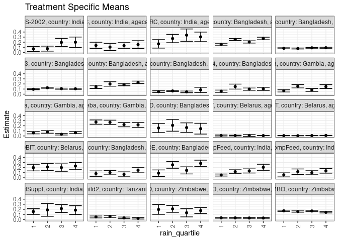

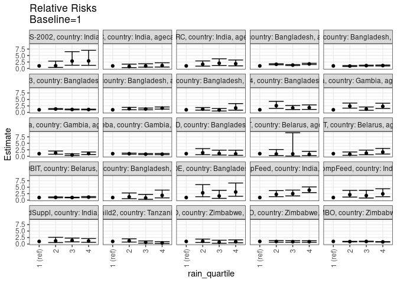

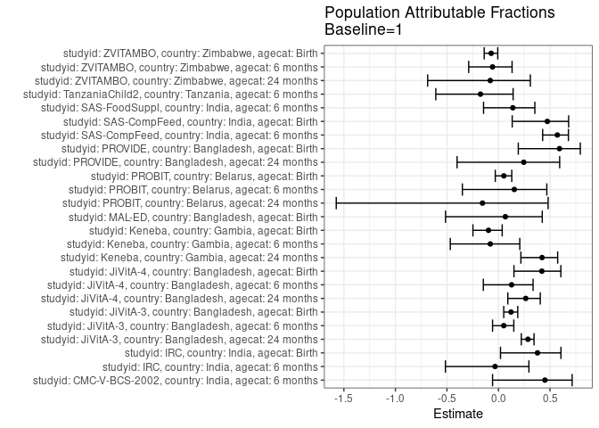

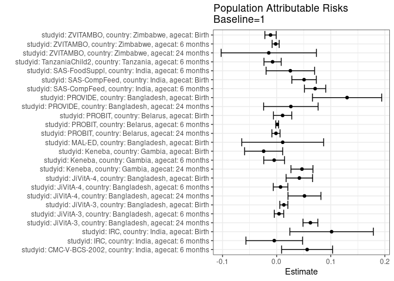

## Results Table

### Parameter: TSM

| studyid | country | agecat | intervention_level | baseline_level | estimate | ci_lower | ci_upper |
| --- | --- | --- | --- | --- | --- | --- | --- |
| CMC-V-BCS-2002 | India | 6 months | 1 | NA | 0.0686275 | 0.0194971 | 0.1177578 |
| CMC-V-BCS-2002 | India | 6 months | 2 | NA | 0.0733945 | 0.0243709 | 0.1224181 |
| CMC-V-BCS-2002 | India | 6 months | 3 | NA | 0.1958763 | 0.1167892 | 0.2749634 |
| CMC-V-BCS-2002 | India | 6 months | 4 | NA | 0.2000000 | 0.0986501 | 0.3013499 |
| IRC | India | Birth | 1 | NA | 0.1666667 | 0.0838403 | 0.2494930 |
| IRC | India | Birth | 2 | NA | 0.2719298 | 0.1901314 | 0.3537282 |
| IRC | India | Birth | 3 | NA | 0.3389831 | 0.2180204 | 0.4599457 |
| IRC | India | Birth | 4 | NA | 0.3043478 | 0.2101872 | 0.3985085 |
| IRC | India | 6 months | 1 | NA | 0.1367521 | 0.0744184 | 0.1990858 |
| IRC | India | 6 months | 2 | NA | 0.1038961 | 0.0356600 | 0.1721322 |
| IRC | India | 6 months | 3 | NA | 0.1317829 | 0.0733403 | 0.1902256 |
| IRC | India | 6 months | 4 | NA | 0.1529412 | 0.0763303 | 0.2295521 |
| JiVitA-3 | Bangladesh | Birth | 1 | NA | 0.0961501 | 0.0871839 | 0.1051163 |
| JiVitA-3 | Bangladesh | Birth | 2 | NA | 0.1251761 | 0.1158834 | 0.1344687 |
| JiVitA-3 | Bangladesh | Birth | 3 | NA | 0.1076605 | 0.0972068 | 0.1181141 |
| JiVitA-3 | Bangladesh | Birth | 4 | NA | 0.1053103 | 0.0943986 | 0.1162219 |
| JiVitA-3 | Bangladesh | 6 months | 1 | NA | 0.0803235 | 0.0706271 | 0.0900198 |
| JiVitA-3 | Bangladesh | 6 months | 2 | NA | 0.0756983 | 0.0662994 | 0.0850973 |
| JiVitA-3 | Bangladesh | 6 months | 3 | NA | 0.0890123 | 0.0809059 | 0.0971186 |
| JiVitA-3 | Bangladesh | 6 months | 4 | NA | 0.0906323 | 0.0804887 | 0.1007759 |
| JiVitA-3 | Bangladesh | 24 months | 1 | NA | 0.1558790 | 0.1406455 | 0.1711124 |
| JiVitA-3 | Bangladesh | 24 months | 2 | NA | 0.2527810 | 0.2343230 | 0.2712390 |
| JiVitA-3 | Bangladesh | 24 months | 3 | NA | 0.2046426 | 0.1828329 | 0.2264524 |
| JiVitA-3 | Bangladesh | 24 months | 4 | NA | 0.2728833 | 0.2480638 | 0.2977028 |
| JiVitA-4 | Bangladesh | Birth | 1 | NA | 0.0577617 | 0.0358950 | 0.0796285 |
| JiVitA-4 | Bangladesh | Birth | 2 | NA | 0.1487179 | 0.0997194 | 0.1977165 |
| JiVitA-4 | Bangladesh | Birth | 3 | NA | 0.0983456 | 0.0763347 | 0.1203564 |
| JiVitA-4 | Bangladesh | Birth | 4 | NA | 0.1040670 | 0.0736580 | 0.1344760 |
| JiVitA-4 | Bangladesh | 6 months | 1 | NA | 0.0496599 | 0.0330492 | 0.0662706 |
| JiVitA-4 | Bangladesh | 6 months | 2 | NA | 0.0626911 | 0.0504690 | 0.0749132 |

[output cut: 70 more lines]

### Parameter: E(Y)

| studyid | country | agecat | intervention_level | baseline_level | estimate | ci_lower | ci_upper |
| --- | --- | --- | --- | --- | --- | --- | --- |
| CMC-V-BCS-2002 | India | 6 months | NA | NA | 0.1250000 | 0.0911644 | 0.1588356 |
| IRC | India | Birth | NA | NA | 0.2682216 | 0.2212677 | 0.3151755 |
| IRC | India | 6 months | NA | NA | 0.1323529 | 0.0994307 | 0.1652752 |
| JiVitA-3 | Bangladesh | Birth | NA | NA | 0.1094765 | 0.1043554 | 0.1145976 |
| JiVitA-3 | Bangladesh | 6 months | NA | NA | 0.0846640 | 0.0798626 | 0.0894653 |
| JiVitA-3 | Bangladesh | 24 months | NA | NA | 0.2182959 | 0.2084450 | 0.2281469 |
| JiVitA-4 | Bangladesh | Birth | NA | NA | 0.0997496 | 0.0843744 | 0.1151247 |
| JiVitA-4 | Bangladesh | 6 months | NA | NA | 0.0569005 | 0.0480577 | 0.0657432 |
| JiVitA-4 | Bangladesh | 24 months | NA | NA | 0.1942978 | 0.1810880 | 0.2075076 |
| Keneba | Gambia | Birth | NA | NA | 0.2482947 | 0.2261720 | 0.2704173 |
| Keneba | Gambia | 6 months | NA | NA | 0.0579225 | 0.0479029 | 0.0679420 |
| Keneba | Gambia | 24 months | NA | NA | 0.1106605 | 0.0958563 | 0.1254646 |
| MAL-ED | Bangladesh | Birth | NA | NA | 0.1674419 | 0.1174176 | 0.2174661 |
| PROBIT | Belarus | Birth | NA | NA | 0.2103206 | 0.1450833 | 0.2755580 |
| PROBIT | Belarus | 6 months | NA | NA | 0.0068541 | 0.0051915 | 0.0085167 |
| PROBIT | Belarus | 24 months | NA | NA | 0.0080605 | 0.0022677 | 0.0138532 |
| PROVIDE | Bangladesh | Birth | NA | NA | 0.2199248 | 0.1846953 | 0.2551543 |
| PROVIDE | Bangladesh | 24 months | NA | NA | 0.1070812 | 0.0818727 | 0.1322897 |
| SAS-CompFeed | India | Birth | NA | NA | 0.1069810 | 0.0760961 | 0.1378659 |
| SAS-CompFeed | India | 6 months | NA | NA | 0.1244378 | 0.0992652 | 0.1496104 |
| SAS-FoodSuppl | India | 6 months | NA | NA | 0.1815789 | 0.1427684 | 0.2203895 |
| TanzaniaChild2 | Tanzania | 6 months | NA | NA | 0.0428994 | 0.0340782 | 0.0517206 |
| ZVITAMBO | Zimbabwe | Birth | NA | NA | 0.1594921 | 0.1531776 | 0.1658066 |
| ZVITAMBO | Zimbabwe | 6 months | NA | NA | 0.0311581 | 0.0274654 | 0.0348509 |
| ZVITAMBO | Zimbabwe | 24 months | NA | NA | 0.1824480 | 0.1460286 | 0.2188675 |

### Parameter: RR

| studyid | country | agecat | intervention_level | baseline_level | estimate | ci_lower | ci_upper |
| --- | --- | --- | --- | --- | --- | --- | --- |
| CMC-V-BCS-2002 | India | 6 months | 1 | 1 | 1.0000000 | 1.0000000 | 1.0000000 |
| CMC-V-BCS-2002 | India | 6 months | 2 | 1 | 1.0694626 | 0.4017372 | 2.8470113 |
| CMC-V-BCS-2002 | India | 6 months | 3 | 1 | 2.8541973 | 1.2546821 | 6.4928342 |
| CMC-V-BCS-2002 | India | 6 months | 4 | 1 | 2.9142857 | 1.2123053 | 7.0057118 |
| IRC | India | Birth | 1 | 1 | 1.0000000 | 1.0000000 | 1.0000000 |
| IRC | India | Birth | 2 | 1 | 1.6315789 | 0.9126908 | 2.9167051 |
| IRC | India | Birth | 3 | 1 | 2.0338983 | 1.1031304 | 3.7500030 |
| IRC | India | Birth | 4 | 1 | 1.8260870 | 1.0169228 | 3.2791021 |
| IRC | India | 6 months | 1 | 1 | 1.0000000 | 1.0000000 | 1.0000000 |
| IRC | India | 6 months | 2 | 1 | 0.7597403 | 0.3415616 | 1.6899008 |
| IRC | India | 6 months | 3 | 1 | 0.9636628 | 0.5101916 | 1.8201906 |
| IRC | India | 6 months | 4 | 1 | 1.1183824 | 0.5681442 | 2.2015170 |
| JiVitA-3 | Bangladesh | Birth | 1 | 1 | 1.0000000 | 1.0000000 | 1.0000000 |
| JiVitA-3 | Bangladesh | Birth | 2 | 1 | 1.3018819 | 1.1604474 | 1.4605543 |
| JiVitA-3 | Bangladesh | Birth | 3 | 1 | 1.1197125 | 0.9784651 | 1.2813498 |
| JiVitA-3 | Bangladesh | Birth | 4 | 1 | 1.0952695 | 0.9570047 | 1.2535104 |
| JiVitA-3 | Bangladesh | 6 months | 1 | 1 | 1.0000000 | 1.0000000 | 1.0000000 |
| JiVitA-3 | Bangladesh | 6 months | 2 | 1 | 0.9424187 | 0.7916524 | 1.1218978 |
| JiVitA-3 | Bangladesh | 6 months | 3 | 1 | 1.1081727 | 0.9506337 | 1.2918190 |
| JiVitA-3 | Bangladesh | 6 months | 4 | 1 | 1.1283420 | 0.9595583 | 1.3268141 |
| JiVitA-3 | Bangladesh | 24 months | 1 | 1 | 1.0000000 | 1.0000000 | 1.0000000 |
| JiVitA-3 | Bangladesh | 24 months | 2 | 1 | 1.6216490 | 1.4343702 | 1.8333798 |
| JiVitA-3 | Bangladesh | 24 months | 3 | 1 | 1.3128303 | 1.1381605 | 1.5143061 |
| JiVitA-3 | Bangladesh | 24 months | 4 | 1 | 1.7506100 | 1.5320775 | 2.0003137 |
| JiVitA-4 | Bangladesh | Birth | 1 | 1 | 1.0000000 | 1.0000000 | 1.0000000 |
| JiVitA-4 | Bangladesh | Birth | 2 | 1 | 2.5746795 | 1.5547911 | 4.2635788 |
| JiVitA-4 | Bangladesh | Birth | 3 | 1 | 1.7026080 | 1.0901280 | 2.6592053 |
| JiVitA-4 | Bangladesh | Birth | 4 | 1 | 1.8016597 | 1.1243036 | 2.8871006 |
| JiVitA-4 | Bangladesh | 6 months | 1 | 1 | 1.0000000 | 1.0000000 | 1.0000000 |
| JiVitA-4 | Bangladesh | 6 months | 2 | 1 | 1.2624105 | 0.8618786 | 1.8490772 |

[output cut: 70 more lines]

### Parameter: PAR

| studyid | country | agecat | intervention_level | baseline_level | estimate | ci_lower | ci_upper |
| --- | --- | --- | --- | --- | --- | --- | --- |
| CMC-V-BCS-2002 | India | 6 months | 1 | NA | 0.0563725 | 0.0092497 | 0.1034954 |
| IRC | India | Birth | 1 | NA | 0.1015549 | 0.0244525 | 0.1786573 |
| IRC | India | 6 months | 1 | NA | -0.0043992 | -0.0567530 | 0.0479546 |
| JiVitA-3 | Bangladesh | Birth | 1 | NA | 0.0133264 | 0.0059149 | 0.0207379 |
| JiVitA-3 | Bangladesh | 6 months | 1 | NA | 0.0043405 | -0.0043769 | 0.0130579 |
| JiVitA-3 | Bangladesh | 24 months | 1 | NA | 0.0624170 | 0.0486806 | 0.0761533 |
| JiVitA-4 | Bangladesh | Birth | 1 | NA | 0.0419878 | 0.0175142 | 0.0664615 |
| JiVitA-4 | Bangladesh | 6 months | 1 | NA | 0.0072406 | -0.0061957 | 0.0206769 |
| JiVitA-4 | Bangladesh | 24 months | 1 | NA | 0.0514406 | 0.0209951 | 0.0818862 |
| Keneba | Gambia | Birth | 1 | NA | -0.0240058 | -0.0591953 | 0.0111837 |
| Keneba | Gambia | 6 months | 1 | NA | -0.0045775 | -0.0238161 | 0.0146610 |
| Keneba | Gambia | 24 months | 1 | NA | 0.0467882 | 0.0265007 | 0.0670758 |
| MAL-ED | Bangladesh | Birth | 1 | NA | 0.0111919 | -0.0644352 | 0.0868190 |
| PROBIT | Belarus | Birth | 1 | NA | 0.0110116 | -0.0059017 | 0.0279248 |
| PROBIT | Belarus | 6 months | 1 | NA | 0.0010514 | -0.0016243 | 0.0037270 |
| PROBIT | Belarus | 24 months | 1 | NA | -0.0012505 | -0.0087797 | 0.0062786 |
| PROVIDE | Bangladesh | Birth | 1 | NA | 0.1301812 | 0.0662288 | 0.1941337 |
| PROVIDE | Bangladesh | 24 months | 1 | NA | 0.0262731 | -0.0240788 | 0.0766250 |
| SAS-CompFeed | India | Birth | 1 | NA | 0.0507039 | 0.0280808 | 0.0733270 |
| SAS-CompFeed | India | 6 months | 1 | NA | 0.0711044 | 0.0514783 | 0.0907306 |
| SAS-FoodSuppl | India | 6 months | 1 | NA | 0.0253289 | -0.0194746 | 0.0701325 |
| TanzaniaChild2 | Tanzania | 6 months | 1 | NA | -0.0074882 | -0.0233893 | 0.0084130 |
| ZVITAMBO | Zimbabwe | Birth | 1 | NA | -0.0112810 | -0.0217550 | -0.0008071 |
| ZVITAMBO | Zimbabwe | 6 months | 1 | NA | -0.0017985 | -0.0083170 | 0.0047199 |
| ZVITAMBO | Zimbabwe | 24 months | 1 | NA | -0.0145217 | -0.1025042 | 0.0734609 |

### Parameter: PAF

| studyid | country | agecat | intervention_level | baseline_level | estimate | ci_lower | ci_upper |
| --- | --- | --- | --- | --- | --- | --- | --- |
| CMC-V-BCS-2002 | India | 6 months | 1 | NA | 0.4509804 | -0.0575661 | 0.7149847 |
| IRC | India | Birth | 1 | NA | 0.3786232 | 0.0197505 | 0.6061114 |
| IRC | India | 6 months | 1 | NA | -0.0332384 | -0.5150945 | 0.2953697 |
| JiVitA-3 | Bangladesh | Birth | 1 | NA | 0.1217284 | 0.0511550 | 0.1870527 |
| JiVitA-3 | Bangladesh | 6 months | 1 | NA | 0.0512676 | -0.0573430 | 0.1487216 |
| JiVitA-3 | Bangladesh | 24 months | 1 | NA | 0.2859282 | 0.2215091 | 0.3450167 |
| JiVitA-4 | Bangladesh | Birth | 1 | NA | 0.4209326 | 0.1503383 | 0.6053499 |
| JiVitA-4 | Bangladesh | 6 months | 1 | NA | 0.1272505 | -0.1468688 | 0.3358510 |
| JiVitA-4 | Bangladesh | 24 months | 1 | NA | 0.2647516 | 0.0906045 | 0.4055499 |
| Keneba | Gambia | Birth | 1 | NA | -0.0966827 | -0.2478904 | 0.0362031 |
| Keneba | Gambia | 6 months | 1 | NA | -0.0790289 | -0.4676356 | 0.2066809 |
| Keneba | Gambia | 24 months | 1 | NA | 0.4228088 | 0.2174331 | 0.5742861 |
| MAL-ED | Bangladesh | Birth | 1 | NA | 0.0668403 | -0.5136727 | 0.4247190 |
| PROBIT | Belarus | Birth | 1 | NA | 0.0523561 | -0.0309034 | 0.1288912 |
| PROBIT | Belarus | 6 months | 1 | NA | 0.1533957 | -0.3502767 | 0.4691911 |
| PROBIT | Belarus | 24 months | 1 | NA | -0.1551443 | -1.5742018 | 0.4816419 |
| PROVIDE | Bangladesh | Birth | 1 | NA | 0.5919351 | 0.1922535 | 0.7938500 |
| PROVIDE | Bangladesh | 24 months | 1 | NA | 0.2453568 | -0.4017659 | 0.5937365 |
| SAS-CompFeed | India | Birth | 1 | NA | 0.4739526 | 0.1332308 | 0.6807387 |
| SAS-CompFeed | India | 6 months | 1 | NA | 0.5714056 | 0.4287222 | 0.6784521 |
| SAS-FoodSuppl | India | 6 months | 1 | NA | 0.1394928 | -0.1447798 | 0.3531745 |
| TanzaniaChild2 | Tanzania | 6 months | 1 | NA | -0.1745523 | -0.6082349 | 0.1421819 |
| ZVITAMBO | Zimbabwe | Birth | 1 | NA | -0.0707311 | -0.1384200 | -0.0070668 |
| ZVITAMBO | Zimbabwe | 6 months | 1 | NA | -0.0577231 | -0.2889263 | 0.1320077 |
| ZVITAMBO | Zimbabwe | 24 months | 1 | NA | -0.0795934 | -0.6873167 | 0.3092453 |